# WSJ Op-Ed Comment Analysis

12/15/2020

This is an RMarkdown document with code to analyze the online comments on the Wall Street Journal opinion piece ‘Is There a Doctor in the White House? Not if You Need an MD.’

## Setup

```r
library(tidyverse)
library(gender)
library(cleanNLP)
library(glmnet)
library(ggpubr)
library(grid)
library(gridExtra)
library(wesanderson)

# Read in the comments
dat_in <- read_csv("cleaned_wsj_comments_1214_noon.csv")

# Proxy for gender using SSA recrods for individuals born from 1932 - 2002
dat_in2 <- dat_in %>%
  mutate(first_name = tolower(str_extract(name, "([^\\s]+)"))) %>%
  mutate(
    birth_year_min = "1932",
    birth_year_max = "2002")

name_gender_probs <- gender_df(
  dat_in2,
  name_col = "first_name",
  year_col = c("birth_year_min", "birth_year_max"),
  method="ssa") %>%
  distinct(name, proportion_female)

dat_final <- dat_in2 %>%
  left_join(name_gender_probs, by=c("first_name"="name")) %>%
  select(name, first_name, prob_name_female=proportion_female, comment)
```

## Comment Summary 1

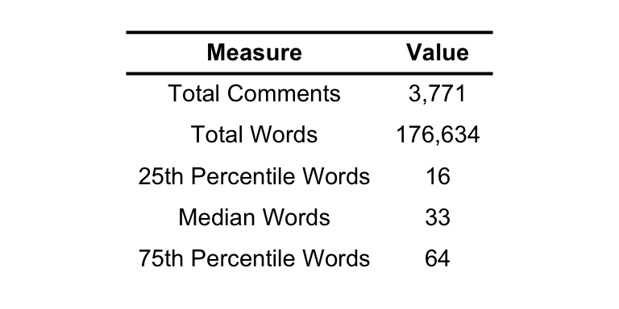

```r
# Summary table of the raw comments
dat_final %>%
  mutate(words = sapply(strsplit(comment, " "), length)) %>%
  summarise(
    `Total Comments` = n(),
    `Total Words` = sum(words),
    `25th Percentile Words`= quantile(words, .25),
    `Median Words`= quantile(words, .5),
    `75th Percentile Words`= quantile(words, .75)
  ) %>%
  gather(key="Measure", value="Value") %>%
  mutate(Value = prettyNum(Value, big.mark=",")) %>%
  ggtexttable(rows = NULL, theme = ttheme("blank")) %>%
  tab_add_hline(at.row = 1:2, row.side = "top", linewidth = 4)
```

## Comment Summary 2

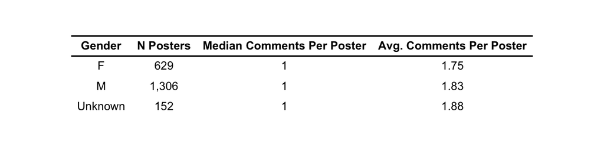

```r
# Many authors comment more than once. Here we make each observation a
# unique author (first name / last name combination)
dat_by_author <- dat_final %>%
  group_by(name) %>%
  summarise(
    first_name = first(first_name),
    prob_name_female = first(prob_name_female),
    comment = paste(comment, collapse = " "),
    num_comments = n()) %>%
  # Only use individuals where we are >= 75% sure about their gender
  mutate(gender = case_when(
    prob_name_female >= 0.75 ~ "F",
    prob_name_female <= 0.25 ~ "M",
    TRUE ~ "Unknown"
  ))


dat_by_author %>%
  group_by(gender) %>%
  summarise(
    `N Posters` = n(),
    `Median Comments Per Poster` = median(num_comments),
    `Avg. Comments Per Poster` = mean(num_comments),
  ) %>%
  mutate(
    `N Posters` = prettyNum(`N Posters`, big.mark=","),
    `Avg. Comments Per Poster` = round(`Avg. Comments Per Poster`, 2)) %>%
  rename(`Gender` = gender) %>%
  ggtexttable(rows = NULL, theme = ttheme("blank")) %>%
  tab_add_hline(at.row = 1:2, row.side = "top", linewidth = 4)
```

## Annotate the Data

```r
# Filter out unknown gender
dat_by_author <- dat_by_author %>%
  filter(gender != "Unknown")

# Start up the udpipe init of cleanNLP.
# cleaNLP will tokenize the text data, allowing us to limit
# to certain parts of speech and lemmatise each word.
# See: https://statsmaths.github.io/cleanNLP/
cnlp_init_udpipe()

# Final preperations for the annotation
dat_to_anno <- dat_by_author %>%
  rename(text=comment) %>%
  mutate(doc_id = 1:n())

# This annotation step takes somewhat long to run
anno <- cnlp_annotate(dat_to_anno)
```

## Find Marginal Effects

Here, we use a simple Lasso regression model, loosely basing our methodology on [Wu, 2018](https://www.aeaweb.org/articles?id=10.1257/pandp.20181101). Specifically, letting $w_i$ denote a vector of indicators for whether each of the lemmatised verbs, adjectives, and nouns used by at least 25 commenters is used by commenter $i$, we estimate a Lasso linear regression model for the probability that the post is authored by a $Female$, as follows:

$\hat{\beta_{\lambda}} = argmin_{\beta}\sum_i(Female_i - \beta_0-w_i'\beta)^2+\lambda||\beta||_1$

where $||\beta||_1 = \sum_{j\geq1}|\beta^j|$

The marginal effect of word $k$ on the probability that an author is $Female$ is estimated by $\hat{\beta_{\lambda}^k}$, the coefficient on the regressor $w_i^k$. We select an optimal tuning parameter $\lambda^*$ through 10-fold cross validation. Importantly, Lasso regression’s functional form helps identify words without over-fitting our model. There are 425 words used by at least 25 commenters.

```r
# Set a seed for reproducibility
set.seed(21)

# Filter to Nouns, Adjectives, and Verbs
df <- anno$token %>%
  left_join(anno$document, by="doc_id") %>%
  filter(upos %in% c("NOUN", "ADJ", "VERB"))

# Build the term-frequency matrix.
# We use binary (0/1 - does this author use the word?).
# min_df is the minimum share of documents the word must be used in to be used,
# we will set is so that a word needs to be in 25 documents.
min_docs_used <- 25

# Build the term frequency matrix
mat <- cnlp_utils_tf(df, doc_var = "doc_id", "binary", min_df=min_docs_used/max(df$doc_id))

# Make the vector of outcome variables as 0/1
gender <- df %>%
  distinct(doc_id, gender) %>%
  mutate(gender_F = as.numeric(gender == "F"))

# Use 10-fold cross validation to set the lambda tuning parameter
cv <- cv.glmnet(mat, gender$gender_F, alpha = 1, family = "gaussian", nfolds=10)

# Now use that lambda to predict
model <- glmnet(mat, gender$gender_F, alpha = 1, lambda = cv$lambda.min, family = "gaussian")

# Get the betas
beta <- coef(model)[-1]

# Get the non-zero betas
final <- tibble(
  word = colnames(mat)[beta != 0],
  coef = beta[beta != 0]
)
```

## Most Predictive Words

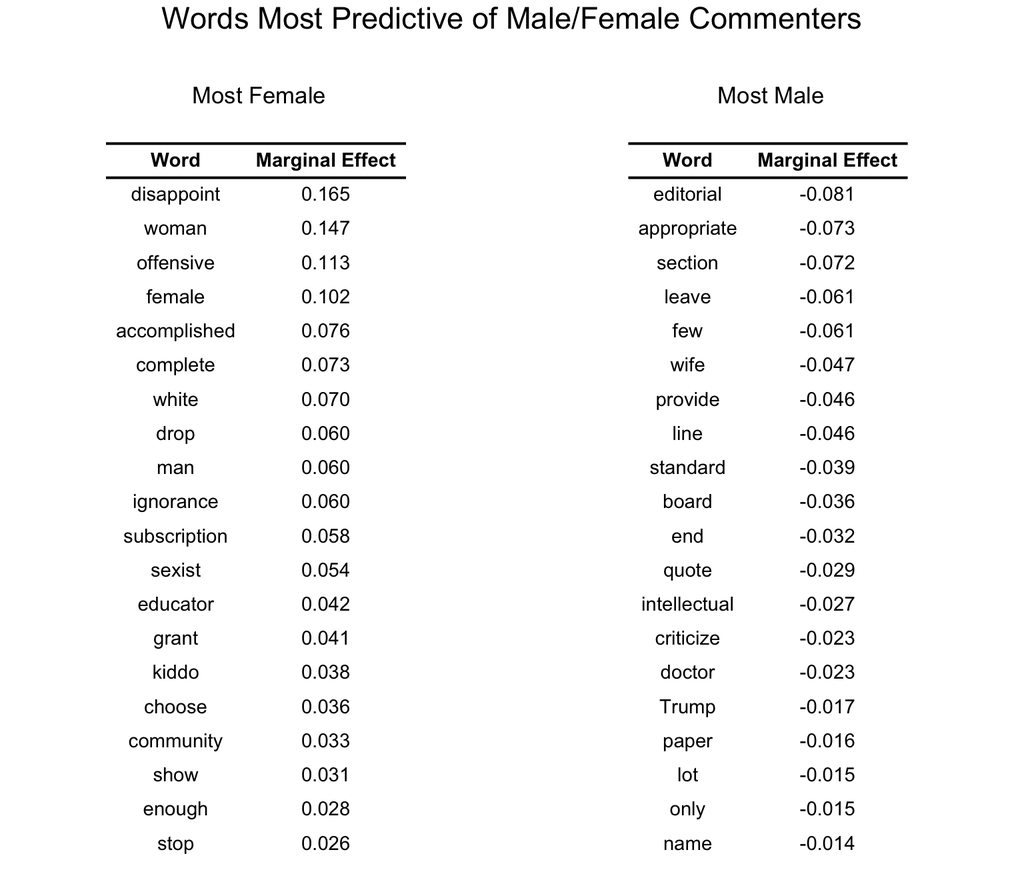

```r
# Most female predictive
female <- final %>%
  arrange(desc(coef)) %>%
  slice(1:20) %>%
  mutate(coef = round(coef, 3)) %>%
  rename(Word=word, `Marginal Effect`=coef)

# Most male predictive
male <- final %>%
  arrange(coef) %>%
  slice(1:20) %>%
  mutate(coef = round(coef, 3)) %>%
  rename(Word=word, `Marginal Effect`=coef)


female_p <- ggtexttable(female, rows = NULL, theme = ttheme("blank")) %>%
  tab_add_hline(at.row = 1:2, row.side = "top", linewidth = 4)

male_p <- ggtexttable(male, rows = NULL, theme = ttheme("blank")) %>%
  tab_add_hline(at.row = 1:2, row.side = "top", linewidth = 4)


grid.arrange(
  female_p + labs(title="\n \n Most Female") +
    theme(legend.position = "none", plot.title = element_text(size=13, hjust=0.5)),
  male_p +
    labs(title = "\n \n Most Male") +
    theme(legend.position = "none", plot.title = element_text(size=13, hjust=0.5)),

  top = textGrob("Words Most Predictive of Male/Female Commenters",
                 gp=gpar(fontsize=17)),

  nrow = 1)
```

## Make a simple bar chart

```r
# Words about sexism/misogyny
numer_sexist <- dat_by_author %>%
  mutate(comment = tolower(comment)) %>%
  filter(
    grepl("sexism", comment) |
      grepl("sexist", comment) |
      grepl("misogyny", comment) |
      grepl("misogynistic", comment) |
      grepl("misogynist", comment)) %>%
  group_by(gender) %>%
  summarise(n_sexist = n())

denom <- dat_by_author %>%
  group_by(gender) %>%
  summarise(n_total = n())
```

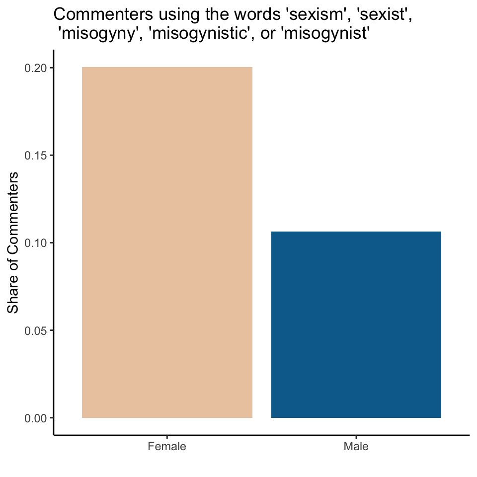

```r
numer_sexist %>%
  inner_join(denom, by="gender") %>%
  mutate(
    share = n_sexist/n_total,
    gender = if_else(gender == "M", "Male", "Female")) %>%
  ggplot() +
  geom_bar(aes(y=share, x=gender, fill=gender), stat="identity") +
  theme_classic() +
  scale_fill_manual(values = wes_palette("Darjeeling2", 2)) +
  labs(x="", y="Share of Commenters", title="Commenters using the words 'sexism', 'sexist', \n 'misogyny', 'misogynistic', or 'misogynist'") +
  theme(legend.position = "none")
```